# Accessing and Analyzing UK Road Crash Data with `stats19`

Cars and Crime Symposium Workshop

Robin Lovelace, Roger Beecham

2026-07-30

## Workshop Overview & Agenda

**Session Duration:** 60 Minutes

- **00:00 – 00:15** | **Introduction to STATS19 & `{stats19}`**
- **00:15 – 00:30** | **Research & Methodological Challenges**
- **00:30 – 01:00** | **Interactive Breakout Groups**
  - **Group 1 (Robin)**: Hands-on code & vignette walkthrough (Laptops out!).
  - **Group 2 (Roger)**: Research design & analysis ideas discussion.
  - **Group 3**: Informal break / walk & networking.

# Part 1: The STATS19 Dataset & Package

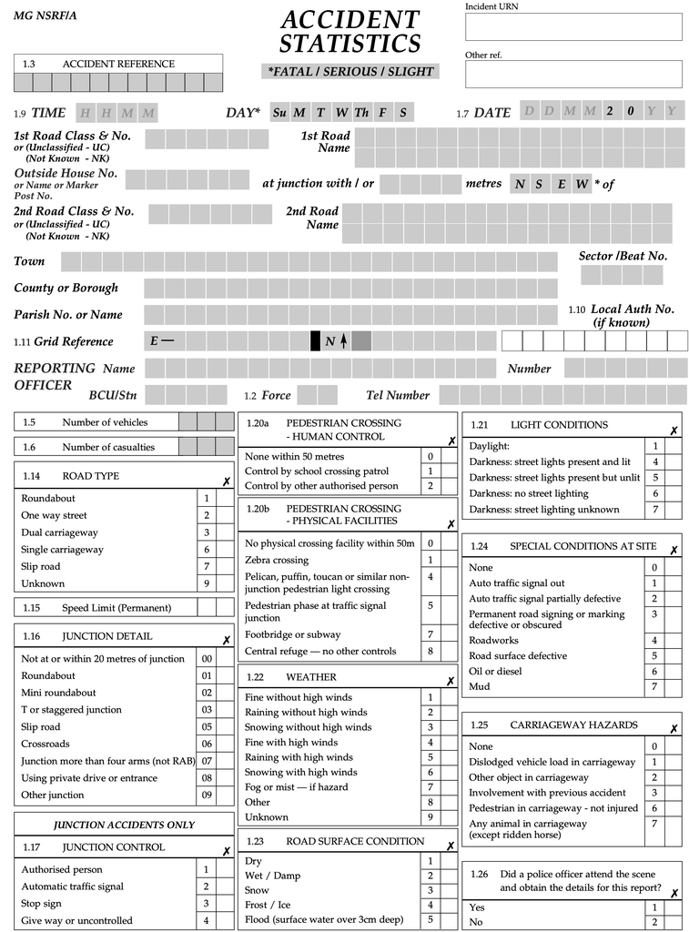

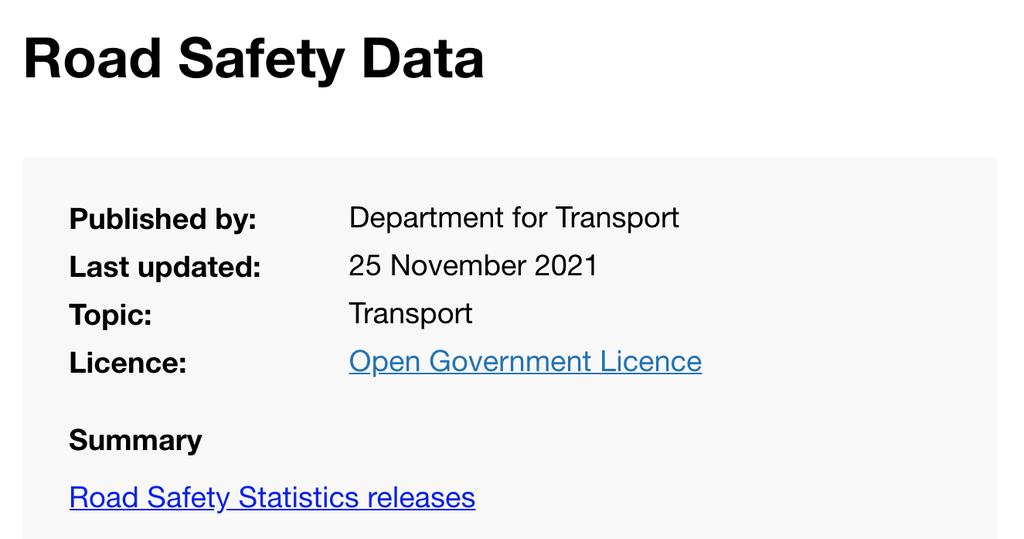

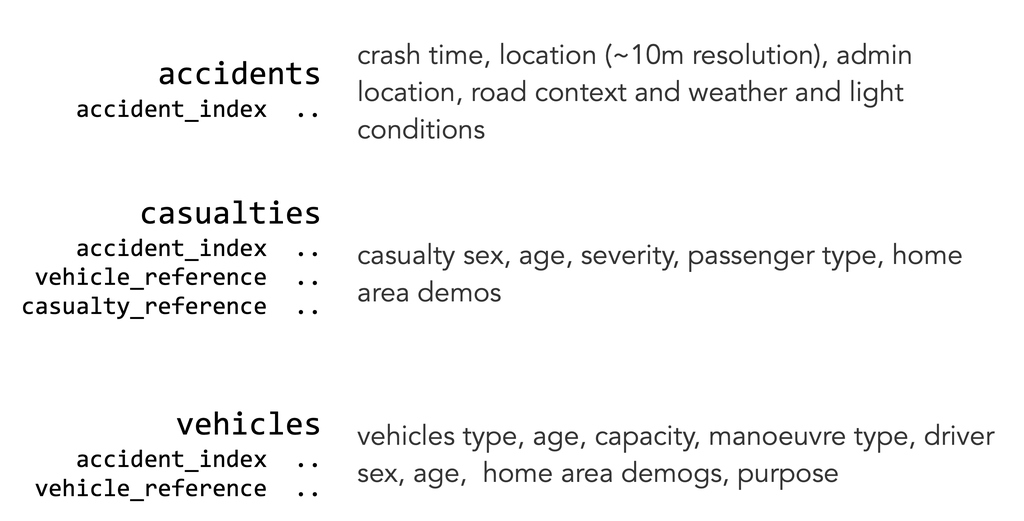

[figure not shown]

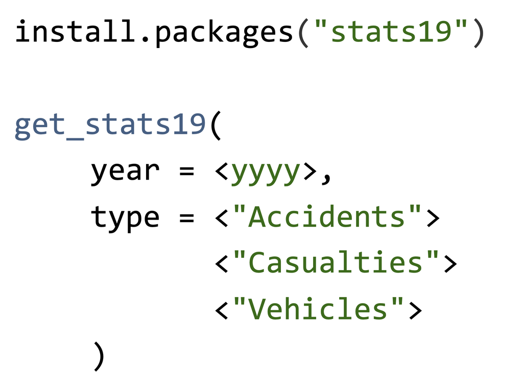

# Part 2: Research & Methodological Challenges

**denominators**

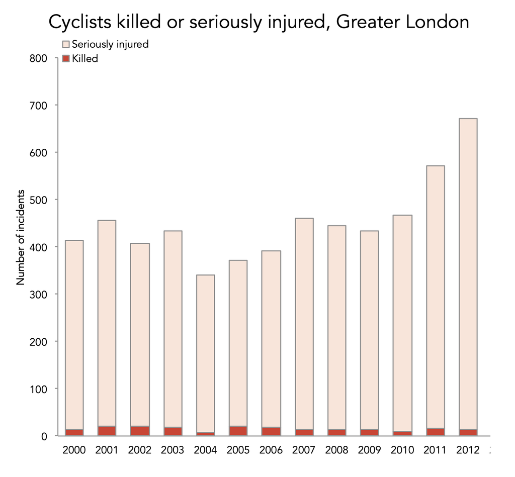

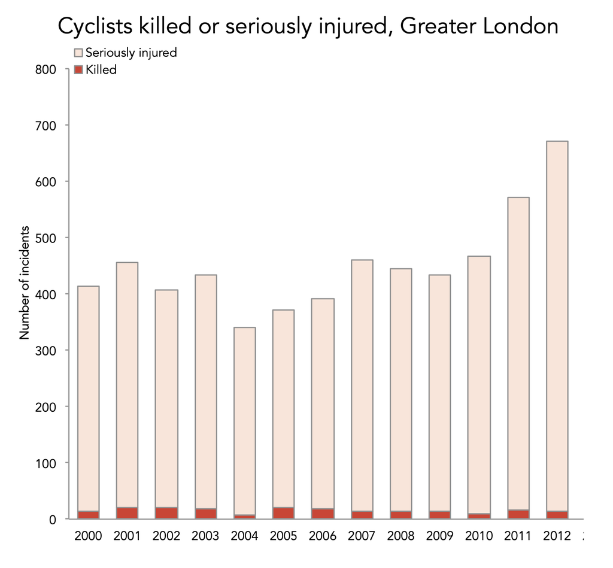

[figure not shown]

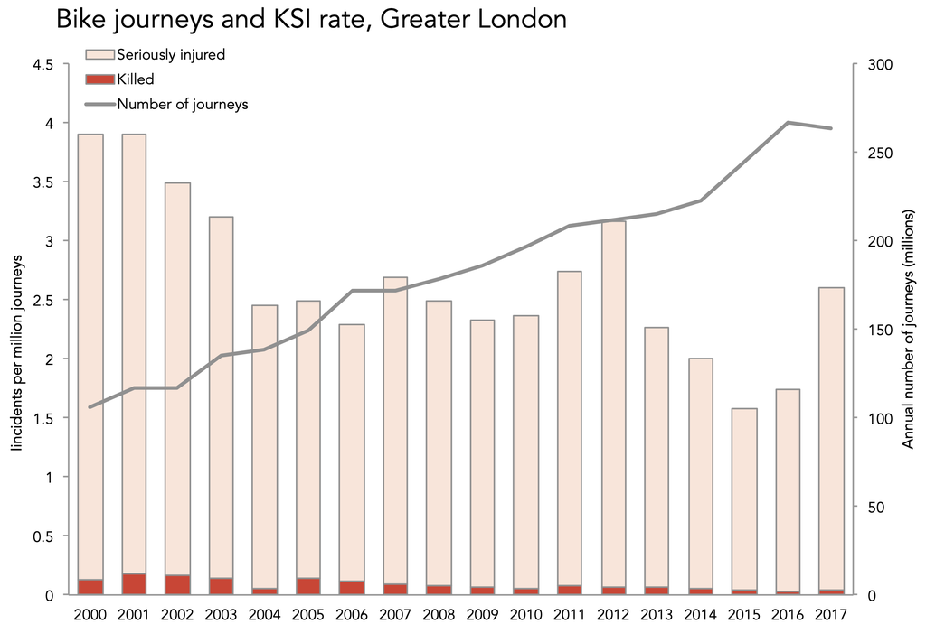

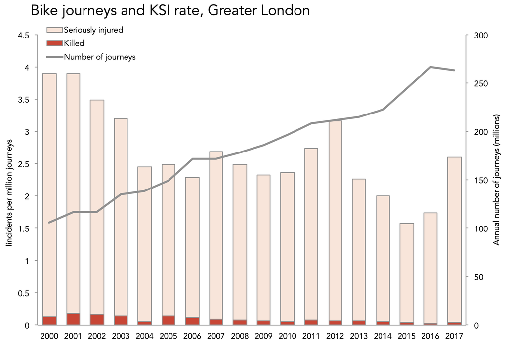

**denominator neglect!**

**low frequency (idiosyncraric) events**

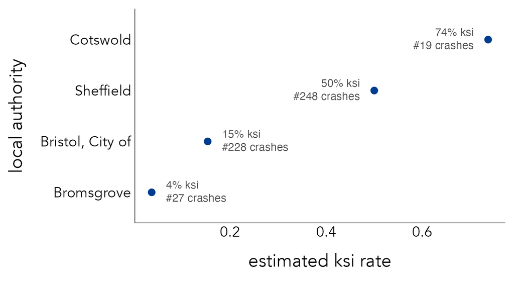

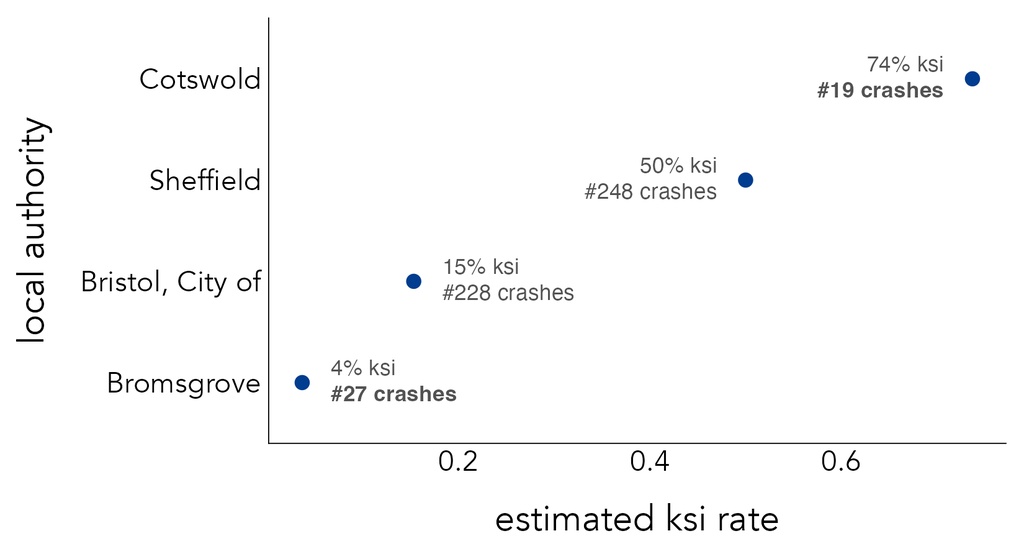

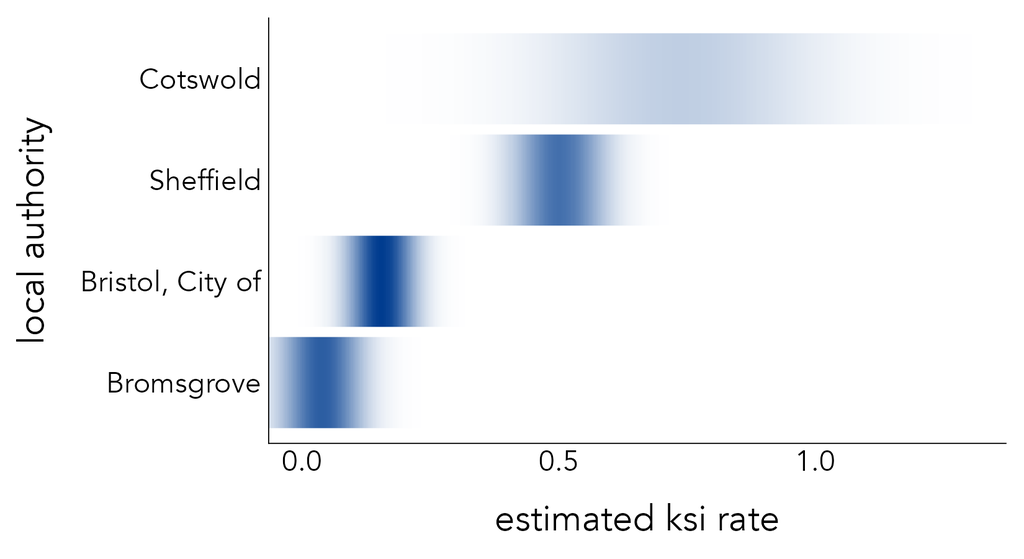

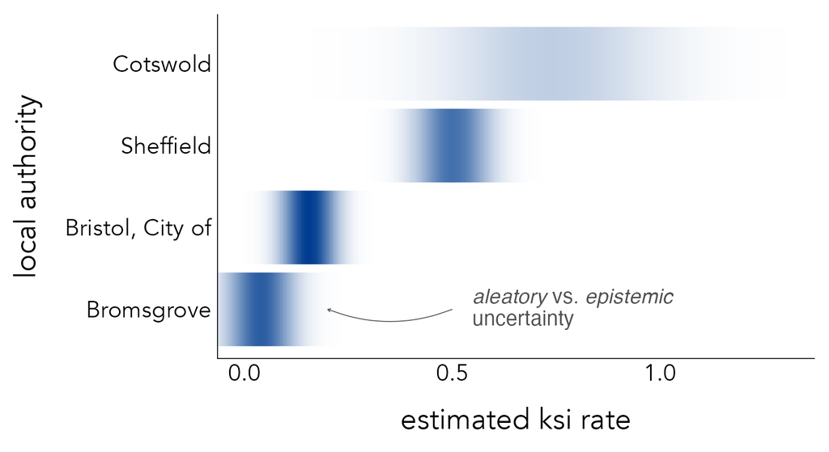

**risk of ‘wonky’ inferences**

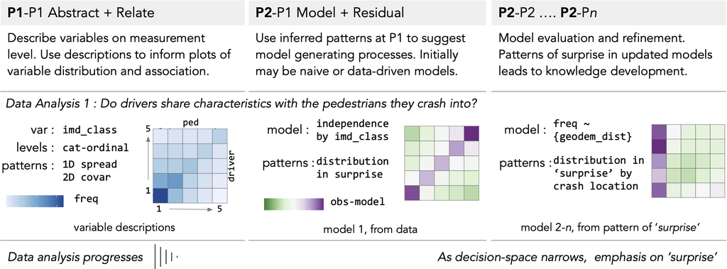

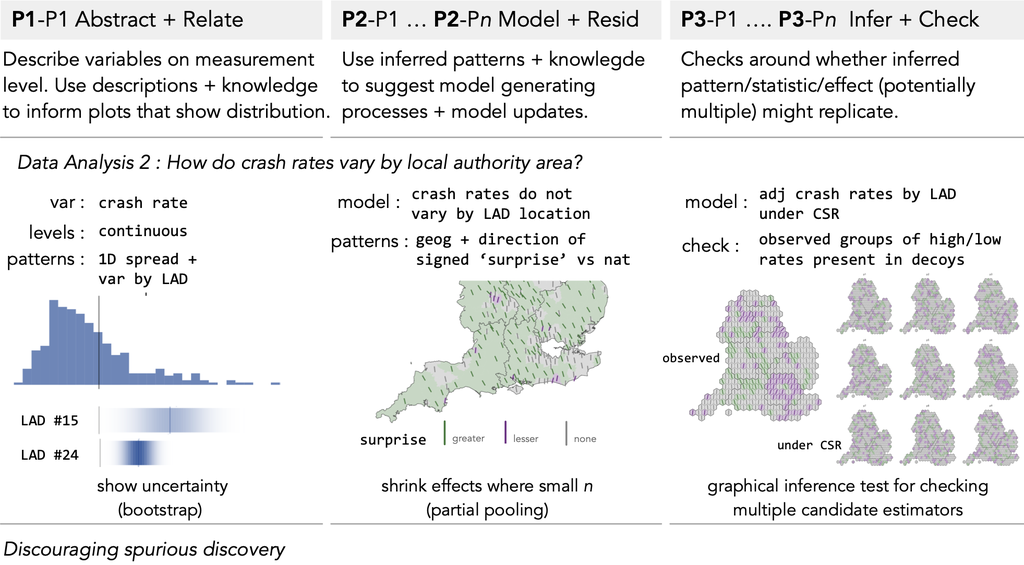

[figure not shown]

# Part 3: Breakout Workshop Groups

## Breakout Group 1: Technical & Hands-On Code

**Led by:** Robin (w/ Reka, Sam Langton)

- **Laptops Open!**
- Walkthrough of core `{stats19}` vignettes and spatial analysis workflows.
- Custom dataset filtering, joining `crashes` + `casualties` + `vehicles`.
- Troubleshooting technical questions or custom research pipelines.

## Breakout Group 2: Research Ideas & Study Design

**Led by:** Roger

- **Conceptual & Strategic Discussion**
- Brainstorming candidate research questions connecting road safety, crime, and transport planning.
- Discussion on data requirements, external denominators, and study design.
- Exploring potential collaboration and grant/paper proposals.

## Breakout Group 3: Walk & Informal Networking

- **Refresh & Recharge**
- Take an early lunch / outdoor walk.
- Informal discussions with colleagues.

## Resources & Links

- **Documentation & Package Website:** docs.ropensci.org/stats19/
- **GitHub Repository:** github.com/ropensci/stats19
- **Report Issues / Feedback:** github.com/ropensci/stats19/issues

Thank you for participating!